# $\color{blue}{\text{Projet de machine learning sur les Etats de Prêt d'une Banque}}$

## Prenom: Mouhammed

## Nom: Niah

## Etudiant

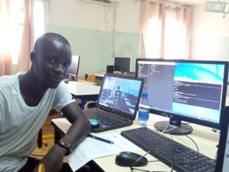

# -Introduction

### Importation des modules utiliser dans le projet

```python
import pandas as pd
import seaborn as sns
import matplotlib.pyplot as plt
import numpy as np
```

=========================================================================================================================

### Exportation du dataset

```python
# importation de notre dataset
df=pd.read_csv("Documents\\loan_bank.csv")
```

====================================================================================================================

### Visualisation de l'entête de notre dataset

```python
# visualisation de l'entête de nos données
df.head(3)
```

|  | Loan_ID | Gender | Married | Dependents | Education | Self_Employed | ApplicantIncome | CoapplicantIncome | LoanAmount | Loan_Amount_Term | Credit_History | Property_Area | Loan_Status |
| --- | --- | --- | --- | --- | --- | --- | --- | --- | --- | --- | --- | --- | --- |
| 0 | LP001002 | Male | No | 0 | Graduate | No | 5849 | 0.0 | NaN | 360.0 | 1.0 | Urban | Y |
| 1 | LP001003 | Male | Yes | 1 | Graduate | No | 4583 | 1508.0 | 128.0 | 360.0 | 1.0 | Rural | N |
| 2 | LP001005 | Male | Yes | 0 | Graduate | Yes | 3000 | 0.0 | 66.0 | 360.0 | 1.0 | Urban | Y |

===================================================================================================================

# 1. Exploration des données

## 1.b) Analyse de forme

### -Variable Target est Loan_Statut

=================================================================================================================

### - Dimension du Dataset

```python
df.shape
```

```
(614, 13)
```

#### le nombre de ligne et de colnne est: (614, 13)

=======================================================================================================================

### -valeur manquante

```python
# visualisation des valeurs manquantes
df.isna().sum()/df.shape[0]
```

```
Loan_ID              0.000000
Gender               0.021173
Married              0.004886
Dependents           0.024430
Education            0.000000
Self_Employed        0.052117
ApplicantIncome      0.000000
CoapplicantIncome    0.000000
LoanAmount           0.035831
Loan_Amount_Term     0.022801
Credit_History       0.081433
Property_Area        0.000000
Loan_Status          0.000000
dtype: float64
```

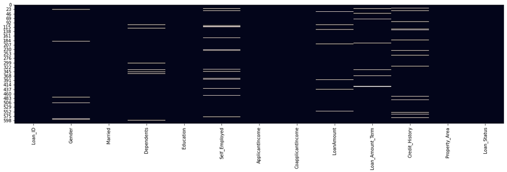

```python
# visualisation des valeurs manquantes sur une figure
plt.figure(figsize=(20,5))
sns.heatmap(df.isna(),cbar=False)
```

### . On a peu de valeurs manquante d'aprés la visualisation de ces dernieres

### la variable qui presente le plus de valeur manquante est la variable $\color{red}{\text{Credit_History}}$. 8% des valeurs de ce derniere sont manquantes

=================================================================================================================

```python
# determination des types de valeurs
df.dtypes
```

```
Loan_ID               object
Gender                object
Married               object
Dependents            object
Education             object
Self_Employed         object
ApplicantIncome        int64
CoapplicantIncome    float64
LoanAmount           float64
Loan_Amount_Term     float64
Credit_History       float64
Property_Area         object
Loan_Status           object
dtype: object
```

### On a deux types de variables qui sont : variables quantitatives et qualitatives

===================================================================================================================

## 1.b) Analyse de fond

### . Separation de notre jeu de donnés en deux classe : La classe des personne qu'on a accordé une credit et la classe des personnes qu'on a refusé une credit

```python
# la classe des personnes qu'on a accodé une credit est:
df_yes=df[df['Loan_Status']=='Y']
# la classe des personne qu'on a refusé une credit
df_not=df[df['Loan_Status']=='N']
```

```python
df_yes.head(3)
```

|  | Loan_ID | Gender | Married | Dependents | Education | Self_Employed | ApplicantIncome | CoapplicantIncome | LoanAmount | Loan_Amount_Term | Credit_History | Property_Area | Loan_Status |
| --- | --- | --- | --- | --- | --- | --- | --- | --- | --- | --- | --- | --- | --- |
| 0 | LP001002 | Male | No | 0 | Graduate | No | 5849 | 0.0 | NaN | 360.0 | 1.0 | Urban | Y |
| 2 | LP001005 | Male | Yes | 0 | Graduate | Yes | 3000 | 0.0 | 66.0 | 360.0 | 1.0 | Urban | Y |
| 3 | LP001006 | Male | Yes | 0 | Not Graduate | No | 2583 | 2358.0 | 120.0 | 360.0 | 1.0 | Urban | Y |

```python
df_not.shape
```

```
(192, 13)
```

====================================================================================================================

### .Variable target (Loan_Statuts) est la variable à predire

```python
df.columns
```

```
Index(['Loan_ID', 'Gender', 'Married', 'Dependents', 'Education',
       'Self_Employed', 'ApplicantIncome', 'CoapplicantIncome', 'LoanAmount',
       'Loan_Amount_Term', 'Credit_History', 'Property_Area', 'Loan_Status'],
      dtype='object')
```

```python
df['Loan_Status'].value_counts(normalize=True)
```

```
Y    0.687296
N    0.312704
Name: Loan_Status, dtype: float64
```

#### l'analyse à fond du target nous montre que 69% des personnes ont profitées du prêt de la banque.

====================================================================================================================

```python
df.head(3)
```

|  | Loan_ID | Gender | Married | Dependents | Education | Self_Employed | ApplicantIncome | CoapplicantIncome | LoanAmount | Loan_Amount_Term | Credit_History | Property_Area | Loan_Status |
| --- | --- | --- | --- | --- | --- | --- | --- | --- | --- | --- | --- | --- | --- |
| 0 | LP001002 | Male | No | 0 | Graduate | No | 5849 | 0.0 | NaN | 360.0 | 1.0 | Urban | Y |
| 1 | LP001003 | Male | Yes | 1 | Graduate | No | 4583 | 1508.0 | 128.0 | 360.0 | 1.0 | Rural | N |
| 2 | LP001005 | Male | Yes | 0 | Graduate | Yes | 3000 | 0.0 | 66.0 | 360.0 | 1.0 | Urban | Y |

### . Signification des variables

```
  - **Loan_ID**: est l'identifiant(numéro de credit) de l'emprunteur
  - __Gender__: est le sex de l'emprunteur
  - __Married__: est la situation matrimoniale
  - __Self_Employed__: montre si l'emprunteur travail pour son compte ou non
  - __ApplicantIncom__: est le revenu de l'emprunteur
  - __CoapplicantIncome__: est le revenue du co-demandeur
  - __Dependants__: le nombre d'enfant de la personne
  - __Education__: montre si l'emprunteur a fait des etudes ou non
  - __loanAmount__: Le Montant demander
  - __Loan_Amount_Term__: Durée du Pret
  - __Credit_History__: historique du credit de l'empunteur
  - __Property_Area__: zone d'habitation de l'emprunteur
  - __Loan_Status__:  Etat du Prêt
```

===================================================================================================================

### . Relation Target/variable

#### relation entre Target/Gender

```python
df['Gender'].value_counts(normalize=True)
```

```
Male      0.813644
Female    0.186356
Name: Gender, dtype: float64
```

```python
df_yes['Gender'].value_counts(normalize=True)
```

```
Male      0.818841
Female    0.181159
Name: Gender, dtype: float64
```

```python
df_not['Gender'].value_counts(normalize=True)
```

```
Male      0.802139
Female    0.197861
Name: Gender, dtype: float64
```

#### il est tres difficile de trouver une relation entre le target et la variable Gender car on constate qu'il y a plus d'homme qu'on a accredité une credit que de femme, et plus d'homme qu'on a refusé une credit que de femme

=====================================================================================================================

#### Il est evident que l'identifiant de la personne n'a aucun impact sur le target

====================================================================================================================

#### -Relation target/ApplicantIncome

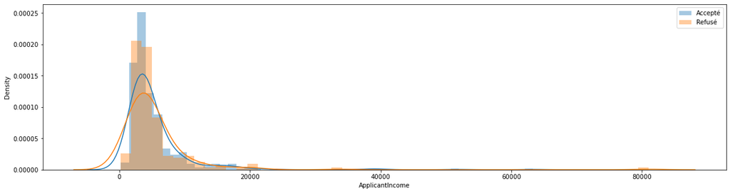

```python
plt.figure(figsize=(20,5))
sns.distplot(df_yes['ApplicantIncome'],label="Accepté")
sns.distplot(df_not['ApplicantIncome'],label="Refusé")
plt.legend()
```

#### il est très difficile de deduire ou de poser une hypothèse trouvant une relation entre le target et la variable ApplicantIncome car les deux distribution sont presque les mêmes. De ce faite nous allons conserver par prudence notre variable pour la suite de notre treavail à moins d'avoir quel que chose de concrête lors du Prè-Traitement de nos donné grâce à la selection des meilleur variables

=======================================================================================================================

#### Relation entre Target/Dependents

```python
df_yes['Dependents'].value_counts(normalize=True)
```

```
0     0.576271
2     0.184019
1     0.159806
3+    0.079903
Name: Dependents, dtype: float64
```

```python
df_not['Dependents'].value_counts(normalize=True)
```

```
0     0.575269
1     0.193548
2     0.134409
3+    0.096774
Name: Dependents, dtype: float64
```

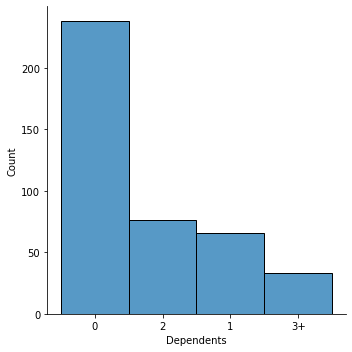

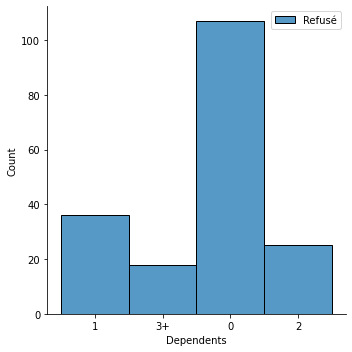

```python
plt.figure(figsize=(3,3))
sns.displot(data=df_yes,x='Dependents', label='Accepté')
sns.displot(data=df_not, x='Dependents', label='Refusé')
plt.legend()
```

===================================================================================================================

```python
df.head(1)
```

|  | Loan_ID | Gender | Married | Dependents | Education | Self_Employed | ApplicantIncome | CoapplicantIncome | LoanAmount | Loan_Amount_Term | Credit_History | Property_Area | Loan_Status |
| --- | --- | --- | --- | --- | --- | --- | --- | --- | --- | --- | --- | --- | --- |
| 0 | LP001002 | Male | No | 0 | Graduate | No | 5849 | 0.0 | NaN | 360.0 | 1.0 | Urban | Y |

#### - Relation entre Target/ Loan_Amount_Tem

#### la variable Amount_Tem n'impact pas sur le pret de credit car par definition la Durée de credit ne peut pas joué un grand role sur ce dernier

======================================================================================================================

#### -Relation entre Target/Educaton

```python
df_yes['Education'].value_counts(normalize=True)
```

```
Graduate        0.805687
Not Graduate    0.194313
Name: Education, dtype: float64
```

```python
df_not['Education'].value_counts(normalize=True)
```

```
Graduate        0.729167
Not Graduate    0.270833
Name: Education, dtype: float64
```

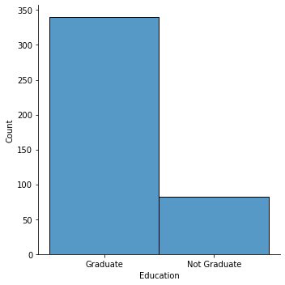

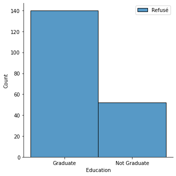

```python
plt.figure()
sns.displot(data=df_yes,x='Education', label='Accepté')
sns.displot(data=df_not, x='Education', label='Refusé')
plt.legend()
```

#### On constate qu'on a accepté comme on a refusé plus de gens qui ont fait des etudes que de gens qui ne l'on pas fait, il est difficile de dire que la variable Education impact sur le fait de prêter ou non un credit a une personne, même si ces le cas elle pèse peu sur ce dernier

======================================================================================================================

#### Relation Target/Credit_History

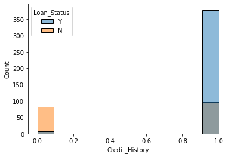

```python
sns.histplot(data=df, x='Credit_History',hue='Loan_Status')
```

#### On peut voir facilement que presque toute les personnes n'ayant jamais une histoire de credit n'ont pas beneficié d'un prêt. On peut donc poser une hypothèse selon la quelle la variable Credit_History joue un role tres important sur le fait d'accorder du credit ou non a une personne pour ne pas dire que c'est le facteur principal

========================================================================================================================

#### - Relation entre Target/LoanAmount

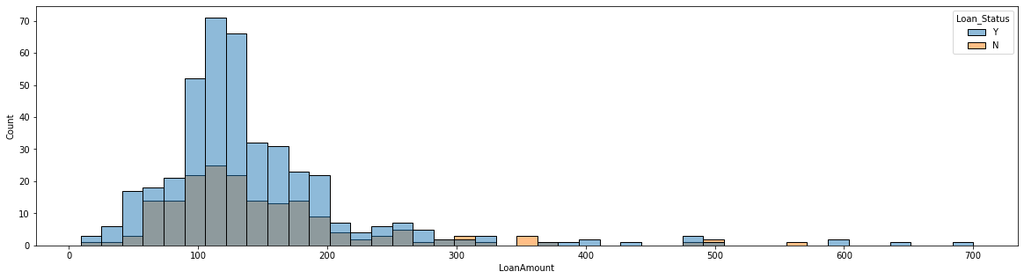

```python
plt.figure(figsize=(20,5))
sns.histplot(data=df, x='LoanAmount',hue='Loan_Status')
```

#### Il est difficile de trouver une relation entre les deux variables à partir du graphe mais ce pendant on voit qu'on a accepté le prêt à toute les personne demandant une somme superieur ou egale à 600. Reste à savoir si c'est une coincidence, mais pour avoir le coeur nette nous allons le regarder lors du prè-traitement de nos données avec la selection des meilleures variables

======================================================================================================================

#### -Relation Target/Coapplicantincom

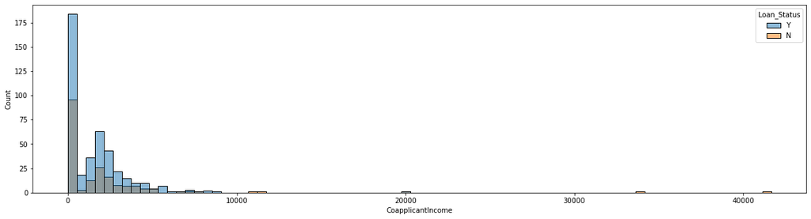

```python
plt.figure(figsize=(20,5))
sns.histplot(data=df, x='CoapplicantIncome',hue='Loan_Status')
plt.show()
```

#### Il est difficile de determiner une relation entre le target et la variable CoapplicantIncome, mais c'est peut etre une variable qui pèse sur notre etude reste a verifier lors du prè-traitement de nos données

==================================================================================================================

#### .Relation entre Target/self_employed

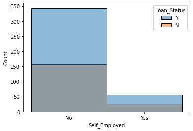

```python
sns.histplot(data=df, x='Self_Employed',hue='Loan_Status')
```

#### l'observation de ce graphe nouspermet de poser une hypothèse selon la quelle la variable Self_employed ne joue âs un grand rôle sur le target

======================================================================================================================

# 2. Pré-Traitement des données et Traitement de nos donéé

#### -Imputation

```python
df.dropna(axis=0,inplace=True)
```

```python
df.shape
```

```
(480, 13)
```

```python
# On elimine la colonne Loan_ID
df.drop('Loan_ID',axis=1,inplace=True)
```

```python
x=df.drop('Loan_Status',axis=1)
y=df['Loan_Status']
```

=========================================================================================================================

#### Notre encodage sera basé sur le changement de toutes les chaines de caracteres en des chiffres que nous allons choisir

```python
df.head(2)
```

|  | Gender | Married | Dependents | Education | Self_Employed | ApplicantIncome | CoapplicantIncome | LoanAmount | Loan_Amount_Term | Credit_History | Property_Area | Loan_Status |
| --- | --- | --- | --- | --- | --- | --- | --- | --- | --- | --- | --- | --- |
| 1 | Male | Yes | 1 | Graduate | No | 4583 | 1508.0 | 128.0 | 360.0 | 1.0 | Rural | N |
| 2 | Male | Yes | 0 | Graduate | Yes | 3000 | 0.0 | 66.0 | 360.0 | 1.0 | Urban | Y |

```python
df['Gender'].replace(['Male','Female'],[1,0],inplace=True)
```

```python
df['Married'].replace(['Yes','No'],[1,0],inplace=True)
```

```python
df['Education'].replace(['Graduate','Not Graduate'],[1,0],inplace=True)
```

```python
df['Self_Employed'].replace(['Yes','No'],[1,0],inplace=True)
```

```python
df['Property_Area'].replace(['Urban','Rural','Semiurban'],[2,1,0],inplace=True)
```

```python
df['Loan_Status'].replace(['Y','N'],[1,0],inplace=True)
```

```python
df['Dependents'].replace('3+',31,inplace=True)
```

```python
df
```

|  | Gender | Married | Dependents | Education | Self_Employed | ApplicantIncome | CoapplicantIncome | LoanAmount | Loan_Amount_Term | Credit_History | Property_Area | Loan_Status |
| --- | --- | --- | --- | --- | --- | --- | --- | --- | --- | --- | --- | --- |
| 1 | 1 | 1 | 1 | 1 | 0 | 4583 | 1508.0 | 128.0 | 360.0 | 1.0 | 1 | 0 |
| 2 | 1 | 1 | 0 | 1 | 1 | 3000 | 0.0 | 66.0 | 360.0 | 1.0 | 2 | 1 |
| 3 | 1 | 1 | 0 | 0 | 0 | 2583 | 2358.0 | 120.0 | 360.0 | 1.0 | 2 | 1 |
| 4 | 1 | 0 | 0 | 1 | 0 | 6000 | 0.0 | 141.0 | 360.0 | 1.0 | 2 | 1 |
| 5 | 1 | 1 | 2 | 1 | 1 | 5417 | 4196.0 | 267.0 | 360.0 | 1.0 | 2 | 1 |
| ... | ... | ... | ... | ... | ... | ... | ... | ... | ... | ... | ... | ... |
| 609 | 0 | 0 | 0 | 1 | 0 | 2900 | 0.0 | 71.0 | 360.0 | 1.0 | 1 | 1 |
| 610 | 1 | 1 | 31 | 1 | 0 | 4106 | 0.0 | 40.0 | 180.0 | 1.0 | 1 | 1 |
| 611 | 1 | 1 | 1 | 1 | 0 | 8072 | 240.0 | 253.0 | 360.0 | 1.0 | 2 | 1 |
| 612 | 1 | 1 | 2 | 1 | 0 | 7583 | 0.0 | 187.0 | 360.0 | 1.0 | 2 | 1 |
| 613 | 0 | 0 | 0 | 1 | 1 | 4583 | 0.0 | 133.0 | 360.0 | 0.0 | 0 | 0 |

480 rows × 12 columns

========================================================================================================================

#### -Division de notre Dataset en donnée d'entrairement et en donnée de test, et entrainement de nos premier model

```python
from sklearn.model_selection import train_test_split
```

##### nous allons d'abord utiliser le modele KNeighborsClassifier qui est un algorithme de classification basé sur les k pus proche voisin.

##### Cet algorithme predit un l'element en se basant sur une vote des elements les proches de ce dernier

```python
from sklearn.neighbors import KNeighborsClassifier
```

```python
x=df.drop('Loan_Status',axis=1)
y=df['Loan_Status']
```

```python
x_train,x_test,y_train,y_test=train_test_split(x,y,test_size=0.3,random_state=0)
```

```python
model=KNeighborsClassifier()
model.fit(x_train,y_train)
model.predict(x_test)
```

```
array([1, 1, 0, 1, 1, 1, 1, 1, 1, 1, 1, 0, 1, 0, 1, 1, 1, 1, 1, 1, 1, 1,
       1, 1, 0, 1, 1, 1, 1, 1, 1, 1, 0, 1, 0, 1, 1, 1, 1, 1, 1, 1, 1, 1,
       1, 1, 1, 1, 1, 1, 1, 0, 0, 1, 1, 1, 1, 1, 1, 1, 1, 0, 1, 1, 0, 1,
       1, 1, 1, 1, 1, 1, 1, 1, 1, 1, 0, 1, 1, 1, 1, 1, 0, 1, 1, 1, 0, 0,
       1, 1, 1, 1, 1, 1, 1, 1, 1, 1, 0, 1, 1, 1, 0, 0, 1, 1, 1, 1, 1, 1,
       1, 1, 1, 0, 1, 1, 1, 1, 1, 1, 1, 1, 1, 1, 1, 1, 1, 1, 1, 0, 1, 0,
       1, 1, 1, 1, 1, 1, 0, 1, 1, 0, 1, 0], dtype=int64)
```

```python
model.score(x_test,y_test)
```

```
0.5972222222222222
```

##### On a une Score de 59.7% avec le modele KNeighborsClassifier

=========================================================================================================================

##### Utilisons le model LogisticRegression pour voir si on peut avoir une meilleur performance

```python
from sklearn.linear_model import LogisticRegression
from sklearn.metrics import confusion_matrix, accuracy_score
```

```python
mod=LogisticRegression()
```

```python
mod.fit(x_train,y_train)
```

```
LogisticRegression()
```

```python
y_pred=mod.predict(x_test)
```

```python
accuracy_score(y_test,y_pred)
```

```
0.75
```

##### on obtient une score de 75% avec le model de LogiticRegression meilleur que celle obtenu avec la methode de KNeighborsClassifier

#### Confusion_matrix donne une matrice dont les elements de la diagonale constitues les bonnes prediction des differentes classe et les autres elements qui ne sont pas dans le diagonale constitue les mauvaise prediction

```python
confusion_matrix(y_test,y_pred)
```

```
array([[15, 34],
       [ 2, 93]], dtype=int64)
```

```
On le test sur (144,) personne
```

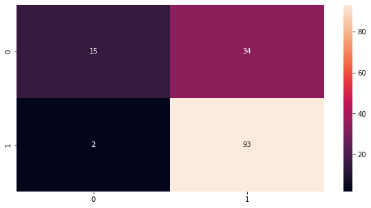

```python
print('On le test sur',y_test.shape,'personne')
plt.figure(figsize=(10,5))
sns.heatmap(confusion_matrix(y_test,y_pred),annot=True)
```

=================================================================================================================

#### Nous allons utiliser make_pipeline, qui sert à assembler plusieur methode de prè-traitement et les traiter ensemble

#### On vas utiliser StandardScaler qui sert à normaliser nos données dans le pipeline

#### On utilisera aussi PolynomialFeatures qui est un polynome permettant de mieux classé nos elements en diminuant les erreurs de sorte a avoir une meilleurs predictionss

```python
from sklearn.pipeline import make_pipeline
from sklearn.preprocessing import PolynomialFeatures
from sklearn.preprocessing import StandardScaler
```

```python
logisticregr=make_pipeline(StandardScaler(),PolynomialFeatures(),LogisticRegression(random_state=0))
```

```python
logisticregr.fit(x_train,y_train)
logisticregr.score(x_test,y_test)
```

```
0.7222222222222222
```

```python
y_prede=logisticregr.predict(x_test)
```

```
On le test sur (144,) personne
```

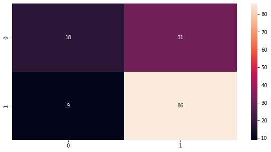

```python
print('On le test sur',y_test.shape,'personne')
plt.figure(figsize=(10,5))
sns.heatmap(confusion_matrix(y_test,y_prede),annot=True)
```

#### On a toujours pas une meilleure performance sur nos predictions au contraire notre performance à même diminuer

#### Cherchons par un autre moyen une maniere de rendre plus performant notre modele

========================================================================================================================

#### Important maintenant SelectKBest et le test de chi2 qui nous viennent du module sklearn.feature_selection,ils permettent de selection les meilleures variables

```python
from sklearn.feature_selection import SelectKBest , chi2
```

```python
chi2(x,y)
```

```
(array([3.57829176e-01, 2.13210084e+00, 1.26416429e-02, 4.54314045e-01,
        4.98919511e-01, 5.34219484e+03, 4.98830718e+03, 1.10437160e+02,
        3.62100083e-01, 1.96177459e+01, 5.47564067e+00]),
 array([5.49714334e-01, 1.44242943e-01, 9.10478457e-01, 5.00293371e-01,
        4.79975265e-01, 0.00000000e+00, 0.00000000e+00, 7.85978268e-26,
        5.47342210e-01, 9.45865863e-06, 1.92832912e-02]))
```

```python
selector=SelectKBest(chi2,k=4)
selector.fit_transform(x,y)
selector.get_support()
```

```
array([False, False, False, False, False,  True,  True,  True, False,
        True, False])
```

#### les 4 meilleures variables selon le test sont: ApplicantIncome CoapplicantIncome LoanAmount Credit_History. Nous allons donc supprimé toute les autres variables pour voir si nous allons voir une meilleure performance

```python
df.head(1)
```

|  | Gender | Married | Dependents | Education | Self_Employed | ApplicantIncome | CoapplicantIncome | LoanAmount | Loan_Amount_Term | Credit_History | Property_Area | Loan_Status |
| --- | --- | --- | --- | --- | --- | --- | --- | --- | --- | --- | --- | --- |
| 1 | 1 | 1 | 1 | 1 | 0 | 4583 | 1508.0 | 128.0 | 360.0 | 1.0 | 1 | 0 |

```python
df.drop(['Gender','Married','Dependents','Education','Self_Employed','Loan_Amount_Term','Property_Area'],axis=1,inplace=True)
```

```python
df.head()
```

|  | ApplicantIncome | CoapplicantIncome | LoanAmount | Credit_History | Loan_Status |
| --- | --- | --- | --- | --- | --- |
| 1 | 4583 | 1508.0 | 128.0 | 1.0 | 0 |
| 2 | 3000 | 0.0 | 66.0 | 1.0 | 1 |
| 3 | 2583 | 2358.0 | 120.0 | 1.0 | 1 |
| 4 | 6000 | 0.0 | 141.0 | 1.0 | 1 |
| 5 | 5417 | 4196.0 | 267.0 | 1.0 | 1 |

```python
c=df.drop('Loan_Status',axis=1)
d=df['Loan_Status']
```

```python
c_train,c_test,d_train,d_test=train_test_split(c,d,test_size=0.3,random_state=0)
```

```python
logisticregr.fit(c_train,d_train)
logisticregr.score(c_test,d_test)
```

```
0.7916666666666666
```

#### Nous venons d'avoir la meilleure score(79%) depuis le debut de notre traitement, donc la selection de variable pése vraiment sur la performance de notre modele

```python
d_prede=logisticregr.predict(c_test)
```

```
On le test sur (144,) personne
```

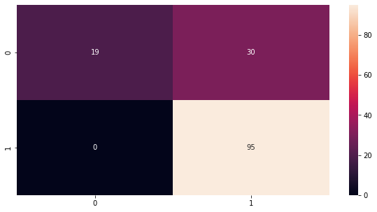

```python
print('On le test sur',d_test.shape,'personne')
plt.figure(figsize=(10,5))
sns.heatmap(confusion_matrix(d_test,d_prede),annot=True)
```

#### On a toujours un probleme sur la classe 0( les personnes ayant pas prêt) car sur les 49 qui devaient etre sur la classe 0, le modele en a fait 30 de maivais classement. Cela s'explique du fait que le modele c'est tres peu entrainer sur cette classe à cause du manque de donnée

=====================================================================================================================

#### Maintenant nous alllons supprimer les valeures manquantes apres avoir selection les meilleures variables a fin d'avoir plus de données

```python
dat=pd.read_csv("Documents\\loan_bank.csv")
```

```python
dat.head(1)
```

|  | Loan_ID | Gender | Married | Dependents | Education | Self_Employed | ApplicantIncome | CoapplicantIncome | LoanAmount | Loan_Amount_Term | Credit_History | Property_Area | Loan_Status |
| --- | --- | --- | --- | --- | --- | --- | --- | --- | --- | --- | --- | --- | --- |
| 0 | LP001002 | Male | No | 0 | Graduate | No | 5849 | 0.0 | NaN | 360.0 | 1.0 | Urban | Y |

```python
dat.drop(['Loan_ID','Gender','Married','Dependents','Education','Self_Employed','Loan_Amount_Term','Property_Area'],axis=1,inplace=True)
```

```python
dat.head()
```

|  | ApplicantIncome | CoapplicantIncome | LoanAmount | Credit_History | Loan_Status |
| --- | --- | --- | --- | --- | --- |
| 0 | 5849 | 0.0 | NaN | 1.0 | Y |
| 1 | 4583 | 1508.0 | 128.0 | 1.0 | N |
| 2 | 3000 | 0.0 | 66.0 | 1.0 | Y |
| 3 | 2583 | 2358.0 | 120.0 | 1.0 | Y |
| 4 | 6000 | 0.0 | 141.0 | 1.0 | Y |

```python
dat['Loan_Status'].replace(['Y','N'],[1,0],inplace=True)
```

```python
dat.dropna(axis=0,inplace=True)
```

```python
dat.shape
```

```
(543, 5)
```

```python
e=dat.drop('Loan_Status',axis=1)
f=dat['Loan_Status']
```

```python
e_train,e_test,f_train,f_test=train_test_split(e,f,test_size=0.3,random_state=0)
```

```python
logisticregr.fit(e_train,f_train)
logisticregr.score(e_test,f_test)
```

```
0.8588957055214724
```

```python
f_prede=logisticregr.predict(e_test)
```

```
On le test sur (163,) personne
```

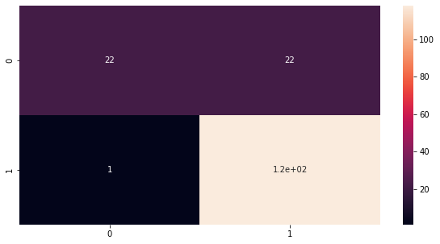

```python
print('On le test sur',f_test.shape,'personne')
plt.figure(figsize=(10,5))
sns.heatmap(confusion_matrix(f_test,f_prede),annot=True)
```

#### On obtient maintenant une score de 86% la meilleure score et que le modele arrive actuellement à faire une prediction de 50% sur la classe 0 chose qu'on a jamiais eu

=================================================================================================================

### Traçons la courbe de validation pour voir si on peuavoir une meilleure performance avec plus de donné

```python
from sklearn.model_selection import learning_curve
```

```
[ 60  87 114 141 168 195 222 249 276 304]
```

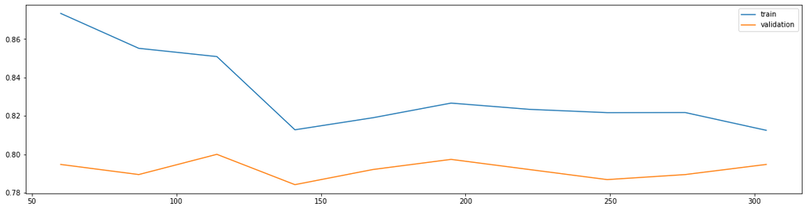

```python
plt.figure(figsize=(20,5))
N,train_score,val_score=learning_curve(logisticregr,e_train,f_train,train_sizes=np.linspace(0.2,1.0,10),cv=5)
print(N)
plt.plot(N,train_score.mean(axis=1),label='train')
plt.plot(N,val_score.mean(axis=1),label='validation')
plt.legend()
plt.show()
```

#### On constate qu'on a une bonne apprentissage du modele.

#### On conste aussi que plus de données ne permet pas d'avoir une meilleure performance